# Biostat 203B Homework 5

Due Mar 22 @ 11:59PM

Author

Chuanliang Chen, UID: 106152237

## Predicting ICU duration

Using the ICU cohort `mimiciv_icu_cohort.rds` you built in Homework 4, develop at least three machine learning approaches (logistic regression with enet regularization, random forest, boosting, SVM, MLP, etc) plus a model stacking approach for predicting whether a patient’s ICU stay will be longer than 2 days. You should use the `los_long` variable as the outcome. You algorithms can use patient demographic information (gender, age at ICU `intime`, marital status, race), ICU admission information (first care unit), the last lab measurements before the ICU stay, and first vital measurements during ICU stay as features. You are welcome to use any feature engineering techniques you think are appropriate; but make sure to not use features that are not available at an ICU stay’s `intime`. For instance, `last_careunit` cannot be used in your algorithms.

1. Data preprocessing and feature engineering.
2. Partition data into 50% training set and 50% test set. Stratify partitioning according to `los_long`. For grading purpose, sort the data by `subject_id`, `hadm_id`, and `stay_id` and use the seed `203` for the initial data split. Below is the sample code.

```r
set.seed(203)

# sort
mimiciv_icu_cohort <- mimiciv_icu_cohort |>
  arrange(subject_id, hadm_id, stay_id)

data_split <- initial_split(
  mimiciv_icu_cohort,
  # stratify by los_long
  strata = "los_long",
  prop = 0.5
  )
```

3. Train and tune the models using the training set.
4. Compare model classification performance on the test set. Report both the area under ROC curve and accuracy for each machine learning algorithm and the model stacking. Interpret the results. What are the most important features in predicting long ICU stays? How do the models compare in terms of performance and interpretability?

```r
suppressPackageStartupMessages({
library(GGally)
library(gtsummary)
library(ranger)
library(tidyverse)
library(tidymodels)
library(xgboost)
})
```

```r
mimiciv_icu_cohort <- readRDS("mimiciv_icu_cohort.rds") %>%
  select(
    -deathtime, -discharge_location, -marital_status,
    -edregtime, -edouttime, -dod, -intime, -outtime, -admittime, -dischtime,
    -anchor_age, -anchor_year, -anchor_year_group, -last_careunit,
    -los, -gender, -age_at_intime
  )
colnames(mimiciv_icu_cohort)
```

```
 [1] "subject_id"
 [2] "hadm_id"
 [3] "stay_id"
 [4] "first_careunit"
 [5] "admission_type"
 [6] "admission_location"
 [7] "insurance"
 [8] "language"
 [9] "race"
[10] "hospital_expire_flag"
[11] "Bicarbonate"
[12] "Chloride"
[13] "Creatinine"
[14] "Glucose"
[15] "Potassium"
[16] "Sodium"
[17] "Hematocrit"
[18] "White Blood Cells"
[19] "Heart Rate"
[20] "Non Invasive Blood Pressure systolic"
[21] "Non Invasive Blood Pressure diastolic"
[22] "Respiratory Rate"
[23] "Temperature Fahrenheit"
[24] "los_long"
```

```r
mimiciv_icu_cohort |> tbl_summary(by = los_long)
```

| **Characteristic** | **FALSE**, N = 38,050<sup>1</sup> | **TRUE**, N = 35,131<sup>1</sup> |
| --- | --- | --- |
| subject_id | 15,002,798 (12,488,949, 17,523,219) | 14,995,832 (12,498,337, 17,496,102) |
| hadm_id | 24,949,943 (22,469,194, 27,466,877) | 24,995,222 (22,499,999, 27,473,223) |
| stay_id | 35,026,375 (32,509,262, 37,504,248) | 34,960,130 (32,470,375, 37,471,693) |
| first_careunit |  |  |
| Cardiac Vascular Intensive Care Unit (CVICU) | 5,827 (15%) | 5,755 (16%) |
| Medical Intensive Care Unit (MICU) | 8,782 (23%) | 7,116 (20%) |
| Medical/Surgical Intensive Care Unit (MICU/SICU) | 7,147 (19%) | 5,586 (16%) |
| Surgical Intensive Care Unit (SICU) | 5,654 (15%) | 5,507 (16%) |
| Other | 10,640 (28%) | 11,167 (32%) |
| admission_type |  |  |
| EW EMER. | 20,735 (54%) | 17,937 (51%) |
| OBSERVATION ADMIT | 4,329 (11%) | 4,645 (13%) |
| SURGICAL SAME DAY ADMISSION | 4,340 (11%) | 3,033 (8.6%) |
| URGENT | 5,494 (14%) | 6,959 (20%) |
| Other | 3,152 (8.3%) | 2,557 (7.3%) |
| admission_location |  |  |
| EMERGENCY ROOM | 19,602 (52%) | 16,279 (46%) |
| PHYSICIAN REFERRAL | 8,986 (24%) | 7,412 (21%) |
| TRANSFER FROM HOSPITAL | 6,839 (18%) | 8,959 (26%) |
| WALK-IN/SELF REFERRAL | 876 (2.3%) | 791 (2.3%) |
| Other | 1,747 (4.6%) | 1,690 (4.8%) |
| insurance |  |  |
| Medicaid | 3,060 (8.0%) | 2,468 (7.0%) |
| Medicare | 16,489 (43%) | 16,602 (47%) |
| Other | 18,501 (49%) | 16,061 (46%) |
| language |  |  |
| ? | 3,692 (9.7%) | 3,751 (11%) |
| ENGLISH | 34,358 (90%) | 31,380 (89%) |
| race |  |  |
| Other | 5,160 (14%) | 5,596 (16%) |
| ASIAN | 1,148 (3.0%) | 1,007 (2.9%) |
| BLACK | 4,311 (11%) | 3,649 (10%) |
| HISPANIC | 1,492 (3.9%) | 1,249 (3.6%) |
| WHITE | 25,939 (68%) | 23,630 (67%) |
| hospital_expire_flag | 3,357 (8.8%) | 4,972 (14%) |
| Bicarbonate | 25.0 (22.0, 27.0) | 24.0 (21.0, 27.0) |
| Unknown | 4,270 | 4,780 |
| Chloride | 102 (98, 105) | 102 (98, 105) |
| Unknown | 4,175 | 4,708 |
| Creatinine | 1.00 (0.80, 1.40) | 1.00 (0.80, 1.60) |
| Unknown | 2,599 | 3,171 |
| Glucose | 118 (98, 153) | 122 (100, 159) |
| Unknown | 4,282 | 4,817 |
| Potassium | 4.20 (3.80, 4.60) | 4.20 (3.80, 4.70) |
| Unknown | 4,189 | 4,712 |
| Sodium | 139.0 (136.0, 141.0) | 138.0 (135.0, 141.0) |
| Unknown | 4,174 | 4,698 |
| Hematocrit | 36 (30, 40) | 35 (29, 40) |
| Unknown | 2,236 | 2,781 |
| White Blood Cells | 9.0 (6.6, 12.6) | 9.7 (7.0, 13.8) |
| Unknown | 2,272 | 2,822 |
| Heart Rate | 85 (74, 99) | 88 (76, 103) |
| Unknown | 17 | 1 |
| Non Invasive Blood Pressure systolic | 122 (107, 139) | 120 (104, 138) |
| Unknown | 732 | 247 |
| Non Invasive Blood Pressure diastolic | 68 (58, 80) | 66 (55, 79) |
| Unknown | 733 | 250 |
| Respiratory Rate | 18.0 (15.0, 22.0) | 19.0 (15.0, 23.0) |
| Unknown | 87 | 11 |
| Temperature Fahrenheit | 98.10 (97.60, 98.60) | 98.20 (97.60, 98.80) |
| Unknown | 1,189 | 173 |

<sup>1</sup> Median (IQR); n (%)

```r
glimpse(mimiciv_icu_cohort)
```

```
Rows: 73,181
Columns: 24
$ subject_id                              <int> 10987724, 11054342, 11304261, …
$ hadm_id                                 <int> 24629596, 23041904, 22601123, …
$ stay_id                                 <int> 35883275, 31109006, 32342980, …
$ first_careunit                          <fct> Other, Other, Other, Other, Ot…
$ admission_type                          <fct> OBSERVATION ADMIT, SURGICAL SA…
$ admission_location                      <fct> EMERGENCY ROOM, PHYSICIAN REFE…
$ insurance                               <chr> "Medicare", "Medicare", "Other…
$ language                                <chr> "ENGLISH", "ENGLISH", "ENGLISH…
$ race                                    <fct> WHITE, WHITE, WHITE, WHITE, WH…
$ hospital_expire_flag                    <int> 0, 0, 0, 0, 0, 0, 0, 0, 0, 0, …
$ Bicarbonate                             <dbl> 25, 24, 27, 27, 25, NA, 25, 29…
$ Chloride                                <dbl> 100, 95, 104, 101, 104, NA, 10…
$ Creatinine                              <dbl> 0.6, 0.8, 0.6, 0.9, 1.0, 0.8, …
$ Glucose                                 <dbl> 136, 185, 87, 121, 94, NA, 105…
$ Potassium                               <dbl> 3.9, 4.5, 3.7, 4.5, 4.7, NA, 3…
$ Sodium                                  <dbl> 137, 134, 144, 142, 141, NA, 1…
$ Hematocrit                              <dbl> 40.8, 34.5, 39.8, 41.0, 43.1, …
$ `White Blood Cells`                     <dbl> 8.8, 4.8, 5.9, 14.7, 5.0, 16.3…
$ `Heart Rate`                            <dbl> 80, 95, 71, 105, 57, 71, 89, 7…
$ `Non Invasive Blood Pressure systolic`  <dbl> 105, 133, 136, 120, 124, 136, …
$ `Non Invasive Blood Pressure diastolic` <dbl> 75, 69, 63, 98, 59, 89, 62, 75…
$ `Respiratory Rate`                      <dbl> 12, 14, 17, 11, 16, 14, 18, 15…
$ `Temperature Fahrenheit`                <dbl> 97.8, 98.0, 98.3, 98.1, 97.6, …
$ los_long                                <fct> FALSE, TRUE, TRUE, FALSE, FALS…
```

```r
set.seed(203)

mimiciv_icu_cohort <- mimiciv_icu_cohort |>
  arrange(subject_id, hadm_id, stay_id)

data_split <- initial_split(
  mimiciv_icu_cohort,
  # stratify by los_long
  strata = "los_long",
  prop = 0.5
  )
data_split
```

```
<Training/Testing/Total>
<36590/36591/73181>
```

```r
mimiciv_icu_cohort_other <- training(data_split) |>
  select(
    -subject_id, -hadm_id, -stay_id)
dim(mimiciv_icu_cohort_other)
```

```
[1] 36590    21
```

```r
mimiciv_icu_cohort_test <- testing(data_split)|>
  select(
    -subject_id, -hadm_id, -stay_id)
dim(mimiciv_icu_cohort_test)
```

```
[1] 36591    21
```

```r
gb_recipe <-
  recipe(
    los_long ~ .,
    data = mimiciv_icu_cohort_other
  ) |>
  step_impute_mean('Bicarbonate', 'Chloride', 'Creatinine', 'Potassium',
                   'Sodium', 'Hematocrit', 'White Blood Cells', 'Heart Rate',
                   'Non Invasive Blood Pressure systolic',
                   'Non Invasive Blood Pressure diastolic',
                   'Respiratory Rate', 'Temperature Fahrenheit', 'Glucose') |>
  #step_mutate(
    #Glucose = replace_na(Glucose, median(Glucose, na.rm = TRUE)),
    #role = "predictor") |>
  step_dummy(all_nominal_predictors()) |>
  step_zv(all_numeric_predictors()) |>
  #step_normalize(all_numeric_predictors()) |>
  print()
```

```
── Recipe ──────────────────────────────────────────────────────────────────────
```

```
── Inputs
```

```
Number of variables by role
```

```
outcome:    1
predictor: 20
```

```
── Operations
```

```
• Mean imputation for: "Bicarbonate", "Chloride", "Creatinine", ...
```

```
• Dummy variables from: all_nominal_predictors()
```

```
• Zero variance filter on: all_numeric_predictors()
```

```r
gb_mod <-
  boost_tree(
    mode = "classification",
    trees = 100,
    tree_depth = tune(),
    learn_rate = tune()
  ) |>
  set_engine("xgboost")
gb_mod
```

```
Boosted Tree Model Specification (classification)

Main Arguments:
  trees = 100
  tree_depth = tune()
  learn_rate = tune()

Computational engine: xgboost
```

```r
gb_wf <- workflow() |>
  add_recipe(gb_recipe) |>
  add_model(gb_mod)
gb_wf
```

```
══ Workflow ════════════════════════════════════════════════════════════════════
Preprocessor: Recipe
Model: boost_tree()

── Preprocessor ────────────────────────────────────────────────────────────────
3 Recipe Steps

• step_impute_mean()
• step_dummy()
• step_zv()

── Model ───────────────────────────────────────────────────────────────────────
Boosted Tree Model Specification (classification)

Main Arguments:
  trees = 100
  tree_depth = tune()
  learn_rate = tune()

Computational engine: xgboost
```

```r
param_grid <- grid_regular(
  tree_depth(range = c(1L, 3L)),
  learn_rate(range = c(-5, 2), trans = log10_trans()),
  levels = c(3, 10)
  )
param_grid
```

```
# A tibble: 30 × 2
   tree_depth learn_rate
        <int>      <dbl>
 1          1  0.00001
 2          2  0.00001
 3          3  0.00001
 4          1  0.0000599
 5          2  0.0000599
 6          3  0.0000599
 7          1  0.000359
 8          2  0.000359
 9          3  0.000359
10          1  0.00215
# ℹ 20 more rows
```

```r
set.seed(203)

folds <- vfold_cv(mimiciv_icu_cohort_other, v = 5)
folds
```

```
#  5-fold cross-validation
# A tibble: 5 × 2
  splits               id
  <list>               <chr>
1 <split [29272/7318]> Fold1
2 <split [29272/7318]> Fold2
3 <split [29272/7318]> Fold3
4 <split [29272/7318]> Fold4
5 <split [29272/7318]> Fold5
```

```r
gb_fit <- gb_wf |>
  tune_grid(
    resamples = folds,
    grid = param_grid,
    metrics = metric_set(roc_auc, accuracy)
    )
gb_fit
```

```
# Tuning results
# 5-fold cross-validation
# A tibble: 5 × 4
  splits               id    .metrics          .notes
  <list>               <chr> <list>            <list>
1 <split [29272/7318]> Fold1 <tibble [60 × 6]> <tibble [0 × 3]>
2 <split [29272/7318]> Fold2 <tibble [60 × 6]> <tibble [0 × 3]>
3 <split [29272/7318]> Fold3 <tibble [60 × 6]> <tibble [0 × 3]>
4 <split [29272/7318]> Fold4 <tibble [60 × 6]> <tibble [0 × 3]>
5 <split [29272/7318]> Fold5 <tibble [60 × 6]> <tibble [0 × 3]>
```

```
# A tibble: 60 × 8
   tree_depth learn_rate .metric  .estimator  mean     n std_err
        <int>      <dbl> <chr>    <chr>      <dbl> <int>   <dbl>
 1          1  0.00001   accuracy binary     0.550     5 0.00338
 2          1  0.00001   roc_auc  binary     0.539     5 0.00172
 3          2  0.00001   accuracy binary     0.563     5 0.00335
 4          2  0.00001   roc_auc  binary     0.558     5 0.00233
 5          3  0.00001   accuracy binary     0.569     5 0.00228
 6          3  0.00001   roc_auc  binary     0.574     5 0.00228
 7          1  0.0000599 accuracy binary     0.550     5 0.00338
 8          1  0.0000599 roc_auc  binary     0.539     5 0.00172
 9          2  0.0000599 accuracy binary     0.563     5 0.00335
10          2  0.0000599 roc_auc  binary     0.558     5 0.00233
   .config
   <chr>
 1 Preprocessor1_Model01
 2 Preprocessor1_Model01
 3 Preprocessor1_Model02
 4 Preprocessor1_Model02
 5 Preprocessor1_Model03
 6 Preprocessor1_Model03
 7 Preprocessor1_Model04
 8 Preprocessor1_Model04
 9 Preprocessor1_Model05
10 Preprocessor1_Model05
# ℹ 50 more rows
```

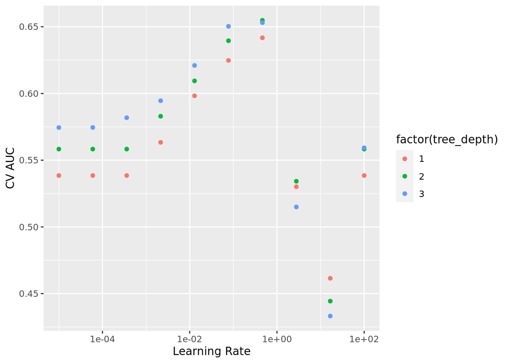

```r
gb_fit |>
  collect_metrics() |>
  print(width = Inf) |>
  filter(.metric == "roc_auc") |>
  ggplot(mapping = aes(x = learn_rate, y = mean, color = factor(tree_depth))) +
  geom_point() +
  labs(x = "Learning Rate", y = "CV AUC") +
  scale_x_log10()
```

```r
gb_fit |>
  show_best(metric = "roc_auc")
```

```
# A tibble: 5 × 8
  tree_depth learn_rate .metric .estimator  mean     n std_err .config
       <int>      <dbl> <chr>   <chr>      <dbl> <int>   <dbl> <chr>
1          2     0.464  roc_auc binary     0.655     5 0.00397 Preprocessor1_Mo…
2          3     0.464  roc_auc binary     0.653     5 0.00384 Preprocessor1_Mo…
3          3     0.0774 roc_auc binary     0.650     5 0.00397 Preprocessor1_Mo…
4          1     0.464  roc_auc binary     0.642     5 0.00329 Preprocessor1_Mo…
5          2     0.0774 roc_auc binary     0.640     5 0.00368 Preprocessor1_Mo…
```

```r
best_gb <- gb_fit |>
  select_best(metric = "roc_auc")
best_gb
```

```
# A tibble: 1 × 3
  tree_depth learn_rate .config
       <int>      <dbl> <chr>
1          2      0.464 Preprocessor1_Model20
```

```r
final_wf <- gb_wf |>
  finalize_workflow(best_gb)
final_wf
```

```
══ Workflow ════════════════════════════════════════════════════════════════════
Preprocessor: Recipe
Model: boost_tree()

── Preprocessor ────────────────────────────────────────────────────────────────
3 Recipe Steps

• step_impute_mean()
• step_dummy()
• step_zv()

── Model ───────────────────────────────────────────────────────────────────────
Boosted Tree Model Specification (classification)

Main Arguments:
  trees = 100
  tree_depth = 2
  learn_rate = 0.464158883361278

Computational engine: xgboost
```

```r
final_fit <-
  final_wf |>
  last_fit(data_split)
final_fit
```

```
# Resampling results
# Manual resampling
# A tibble: 1 × 6
  splits                id             .metrics .notes   .predictions .workflow
  <list>                <chr>          <list>   <list>   <list>       <list>
1 <split [36590/36591]> train/test sp… <tibble> <tibble> <tibble>     <workflow>
```

```r
final_fit |>
  collect_metrics()
```

```
# A tibble: 3 × 4
  .metric     .estimator .estimate .config
  <chr>       <chr>          <dbl> <chr>
1 accuracy    binary         0.608 Preprocessor1_Model1
2 roc_auc     binary         0.653 Preprocessor1_Model1
3 brier_class binary         0.232 Preprocessor1_Model1
```